# GLM Model

Danielle van Os

06/01/2021

```r
library(tidyverse)
library(stats) # For linear models
library(MASS) # For random data generation with exact means
library(knitr) # for nice tables

rm(list = ls())
```

## GLM Parameters

- number of groups
- mean for each group/s
- sd for each group/s
- presence of continuous variable (e.g., for ANCOVA)

## Linear Model - 1 predictor

### Generate sample data

To make it faster consider running the lm model, saving it, and adding aspects of that to the graph, rather than running the lm model twice.

```r
# Parameters
sample_size <- 400
intercept <- 10
slope <- 3.4
sd <- 5
mean <- 0

x <- mvrnorm(n = sample_size, mu = 0, Sigma = sd, empirical = TRUE)
y <- intercept + slope*x + mvrnorm(n = sample_size, mu = 0, Sigma = sd, empirical = TRUE)
df <- tibble(x = x, y = y)

lm <- summary(lm(formula = y ~ x, data = df))
```

### Plot Linear Model

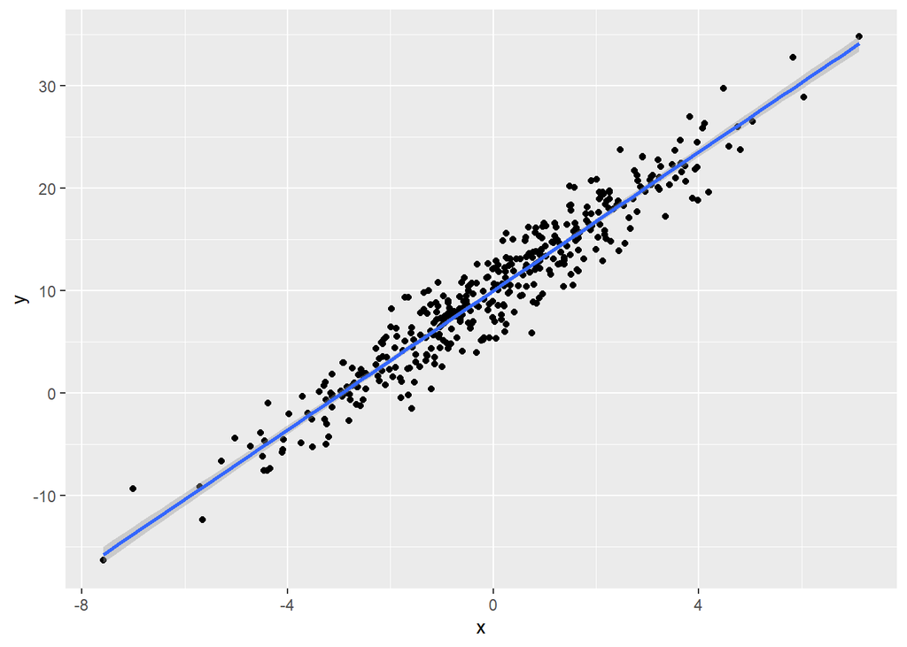

```r
ggplot(data = df, mapping = aes(x = x, y = y)) +
  geom_point() +
  stat_smooth(method = "lm")
```

## t-test - 1 variable 2 groups

```r
# Parameters
group_size <- 200
mean_g1 <- 10
mean_g2 <- 12
sd_g1 <- 0.3
sd_g2 <- 0.3

# Data generation
group_1 <- mvrnorm(n = group_size, mu = mean_g1, Sigma = sd_g1, empirical = TRUE)
group_2 <- mvrnorm(n = group_size, mu = mean_g2, Sigma = sd_g2, empirical = TRUE)
data <- c(group_1, group_2)

# Data frame
df <- tibble(group = rep(c(0, 1), each = group_size),
             y = data)

# Linear model and t.test function
t.test(formula = y ~ group, data = df)
```

```
##
##  Welch Two Sample t-test
##
## data:  y by group
## t = -36.515, df = 398, p-value < 2.2e-16
## alternative hypothesis: true difference in means is not equal to 0
## 95 percent confidence interval:
##  -2.107679 -1.892321
## sample estimates:
## mean in group 0 mean in group 1
##              10              12
```

```r
t_test <- summary(lm(formula = y ~ 1 + group, data = df)) # The '1' is a way of writing 1*B0 or 1*intercept, which in this case is 1*10.

# Output
t_test
```

```
##
## Call:
## lm(formula = y ~ 1 + group, data = df)
##
## Residuals:
##      Min       1Q   Median       3Q      Max
## -1.39174 -0.39493  0.00793  0.38369  1.58554
##
## Coefficients:
##             Estimate Std. Error t value Pr(>|t|)
## (Intercept) 10.00000    0.03873  258.20   <2e-16 ***
## group        2.00000    0.05477   36.52   <2e-16 ***
## ---
## Signif. codes:  0 '***' 0.001 '**' 0.01 '*' 0.05 '.' 0.1 ' ' 1
##
## Residual standard error: 0.5477 on 398 degrees of freedom
## Multiple R-squared:  0.7701, Adjusted R-squared:  0.7695
## F-statistic:  1333 on 1 and 398 DF,  p-value: < 2.2e-16
```

```r
knitr::kable(coefficients(t_test), digits=3)
```

|  | Estimate | Std. Error | t value | Pr(>\|t\|) |
| --- | --- | --- | --- | --- |
| (Intercept) | 10 | 0.039 | 258.199 | 0 |
| group | 2 | 0.055 | 36.515 | 0 |

The x estimate indicates the amount that the second group mean differs from the first. If it is negative it means that the mean of the second group is less than that of the first group, whereas if it is positive, the mean of the second group is greater than that of hte first group.

### Plot T-Test

NOTE TO SELF: Eventually animate the transition from a standard graph to the density plots NOTE 2: add intercept horizontal line as well

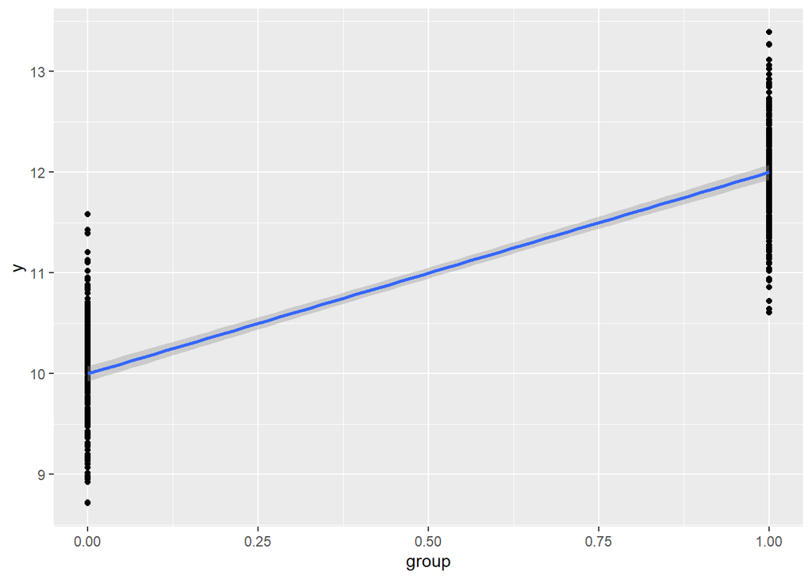

```r
# Step 1 - standard graph
ggplot(data = df, mapping = aes(x =group, y = y)) +
  geom_point() +
  stat_smooth(method = "lm")
```

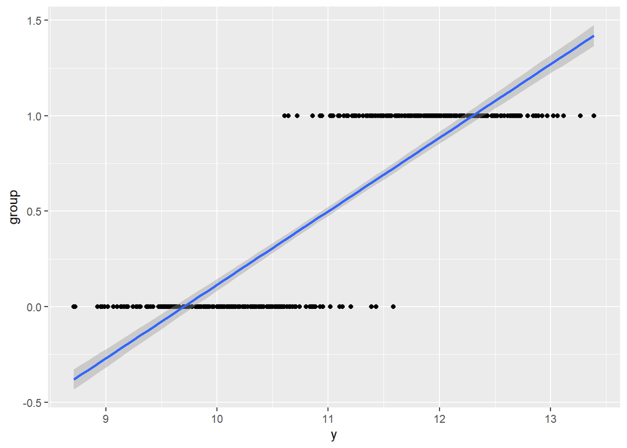

```r
# Step 2 - change axes
ggplot(data = df, mapping = aes(x = y, y =group)) +
  geom_point() +
  stat_smooth(method = "lm")
```

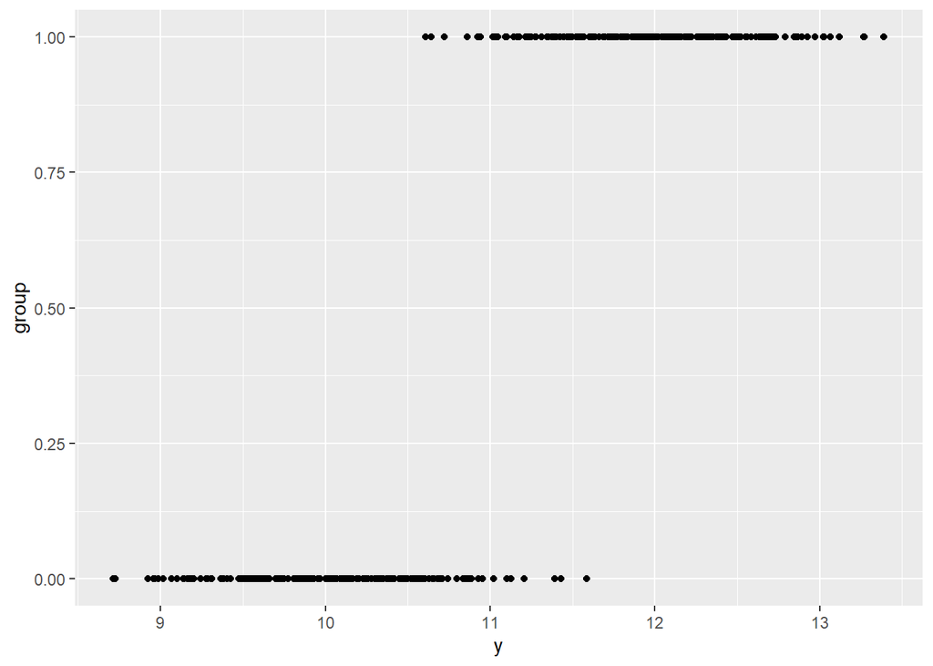

```r
# Step 3 - remove regression line
ggplot(data = df, mapping = aes(x = y, y =group)) +
  geom_point()
```

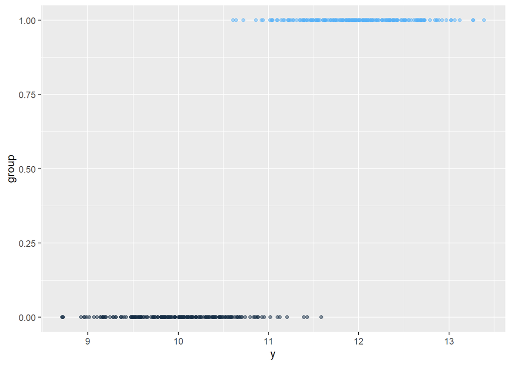

```r
# Step 4 - change colours
ggplot(data = df, mapping = aes(x = y, y =group, color =group)) +
  geom_point(alpha = 0.5) +
  theme(legend.position = "none")
```

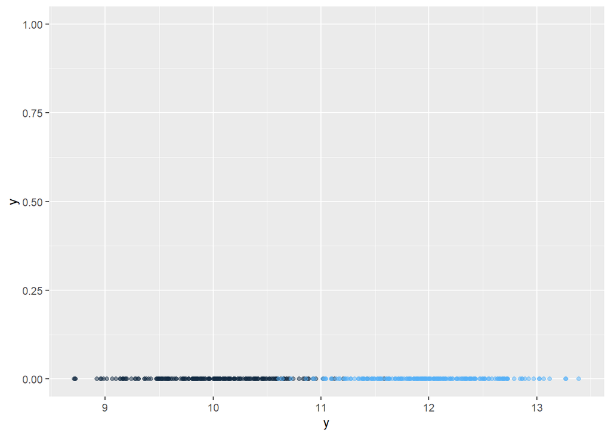

```r
# Step 5 - move dots from second graph to the x axis
ggplot(data = df, mapping = aes(x = y, y = 0, color =group)) +
  geom_point(alpha = 0.5) +
  ylim(0, 1) +
  theme(legend.position = "none")
```

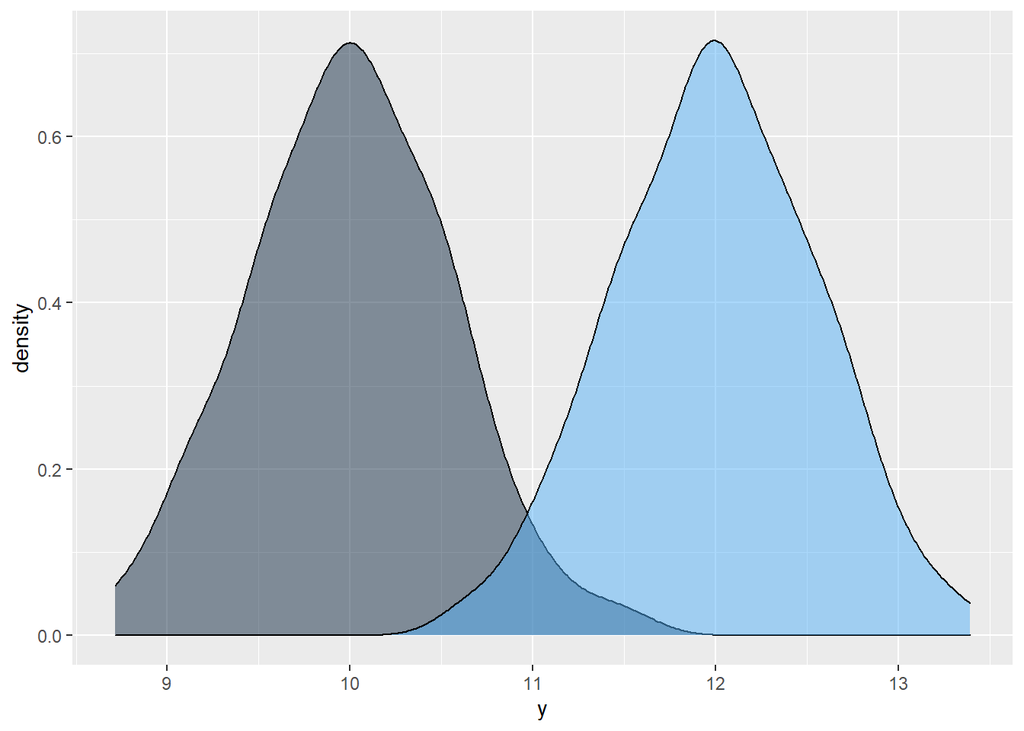

```r
# Step 6 - turn into density plots for easier viewing (how t-tests are usually displayed)
ggplot(data = df, aes(x = y, group =group, fill =group)) +
  geom_density(alpha = 0.5) +
  theme(legend.position = "none")
```

## ANOVA - 3 groups

```r
# Parameters
group_size <- 200
mean_g1 <- 10
mean_g2 <- 12
mean_g3 <- 7
sd_g1 <- 0.3
sd_g2 <- 0.3
sd_g3 <- 0.3

# Data generation
group_1 <- mvrnorm(n = group_size, mu = mean_g1, Sigma = sd_g1, empirical = TRUE)
group_2 <- mvrnorm(n = group_size, mu = mean_g2, Sigma = sd_g2, empirical = TRUE)
group_3 <- mvrnorm(n = group_size, mu = mean_g3, Sigma = sd_g3, empirical = TRUE)
data <- c(group_1, group_2, group_3)

# Data frame
df <- tibble(group_label = rep(c("group_1", "group_2", "group_3"), each = group_size),
             group_n = as_factor(rep(c(0, 1, 2), each = group_size)),
             group_2 = rep(c(0,1,0), each = group_size),
             group_3 = rep(c(0,0,1), each = group_size),
             y = data)

# Linear model and anova function
summary(aov(y ~ group_label, data = df))
```

```
##              Df Sum Sq Mean Sq F value Pr(>F)
## group_label   2 2533.3  1266.7    4222 <2e-16 ***
## Residuals   597  179.1     0.3
## ---
## Signif. codes:  0 '***' 0.001 '**' 0.01 '*' 0.05 '.' 0.1 ' ' 1
```

```r
anova <- summary(lm(formula = y ~ 1 + group_2 + group_3, data = df))

# Output
anova
```

```
##
## Call:
## lm(formula = y ~ 1 + group_2 + group_3, data = df)
##
## Residuals:
##      Min       1Q   Median       3Q      Max
## -1.54285 -0.36086  0.03207  0.39934  1.46295
##
## Coefficients:
##             Estimate Std. Error t value Pr(>|t|)
## (Intercept) 10.00000    0.03873  258.20   <2e-16 ***
## group_2      2.00000    0.05477   36.52   <2e-16 ***
## group_3     -3.00000    0.05477  -54.77   <2e-16 ***
## ---
## Signif. codes:  0 '***' 0.001 '**' 0.01 '*' 0.05 '.' 0.1 ' ' 1
##
## Residual standard error: 0.5477 on 597 degrees of freedom
## Multiple R-squared:  0.934,  Adjusted R-squared:  0.9337
## F-statistic:  4222 on 2 and 597 DF,  p-value: < 2.2e-16
```

```r
knitr::kable(coefficients(anova), digits=3)
```

|  | Estimate | Std. Error | t value | Pr(>\|t\|) |
| --- | --- | --- | --- | --- |
| (Intercept) | 10 | 0.039 | 258.199 | 0 |
| group_2 | 2 | 0.055 | 36.515 | 0 |
| group_3 | -3 | 0.055 | -54.772 | 0 |

What is a t-test not simply an ANOVA with two groups, or an ANOVA simply a t-test with 3+ groups?

### Plot ANOVA

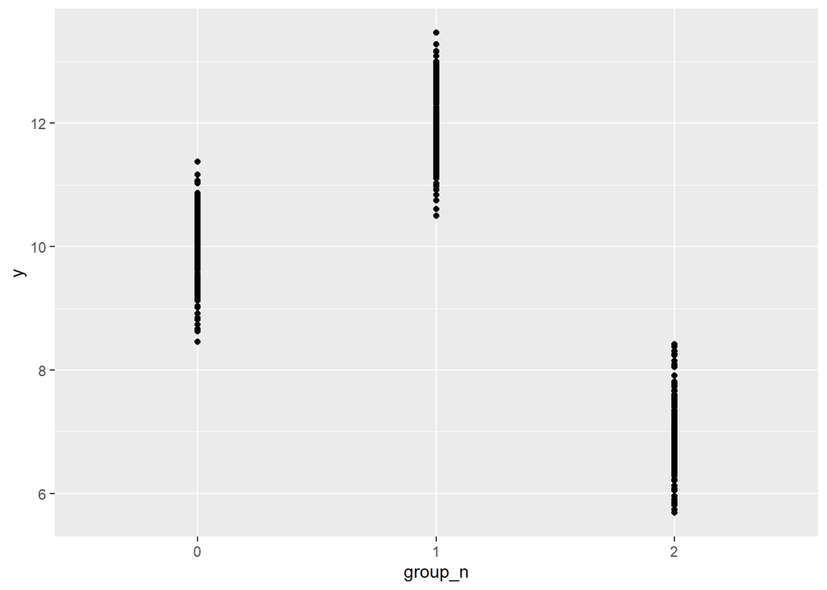

```r
# Step 1 - standard graph
ggplot(data = df, mapping = aes(x = group_n, y = y)) +
  geom_point()
```

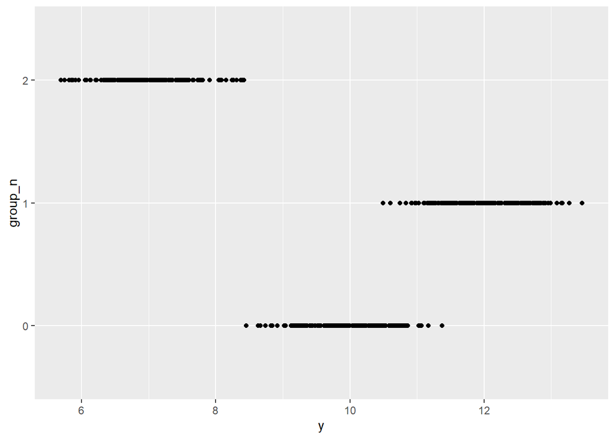

```r
# Step 2 - change axes
ggplot(data = df, mapping = aes(x = y, y = group_n)) +
  geom_point()
```

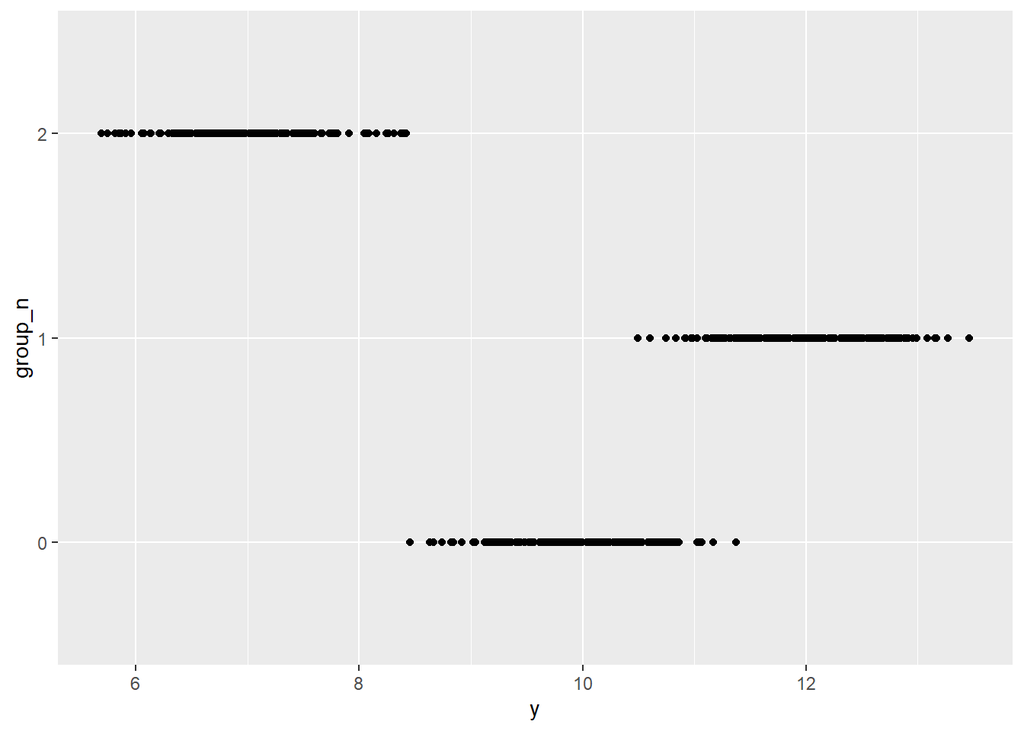

```r
# Step 3 - remove regression line
ggplot(data = df, mapping = aes(x = y, y = group_n)) +
  geom_point()
```

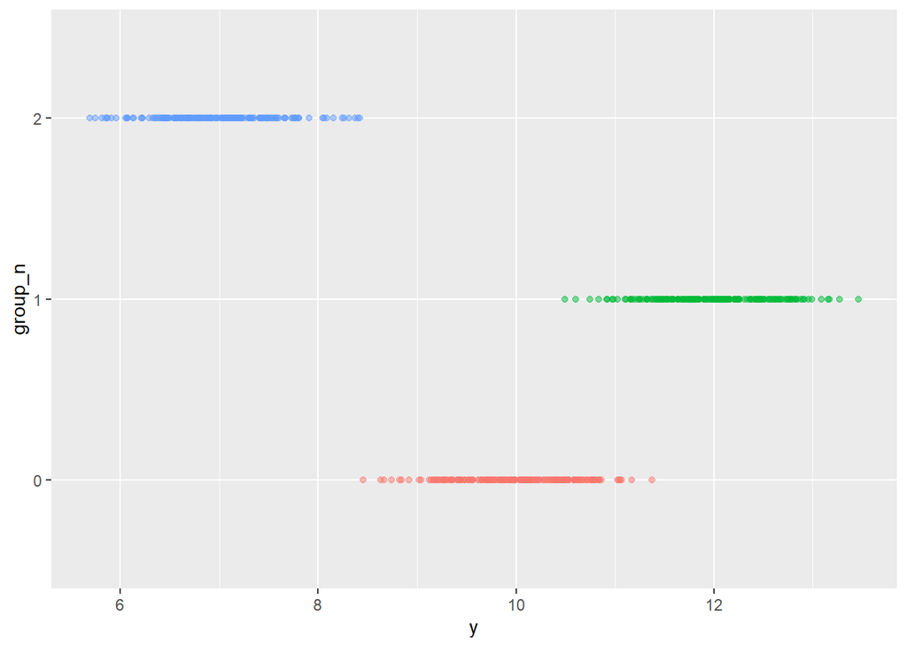

```r
# Step 4 - change colours
ggplot(data = df, mapping = aes(x = y, y = group_n, color = group_n)) +
  geom_point(alpha = 0.5) +
  theme(legend.position = "none")
```

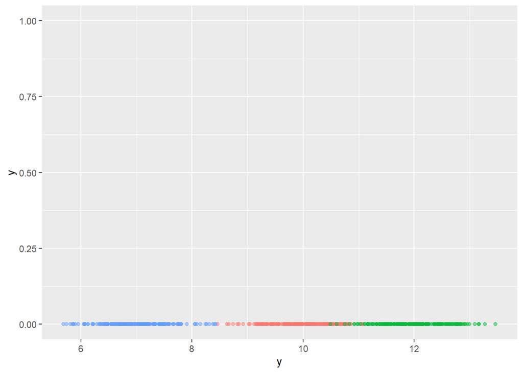

```r
# Step 5 - move dots from second graph to the x axis
ggplot(data = df, mapping = aes(x = y, y = 0, color = group_n)) +
  geom_point(alpha = 0.5) +
  ylim(0, 1) +
  theme(legend.position = "none")
```

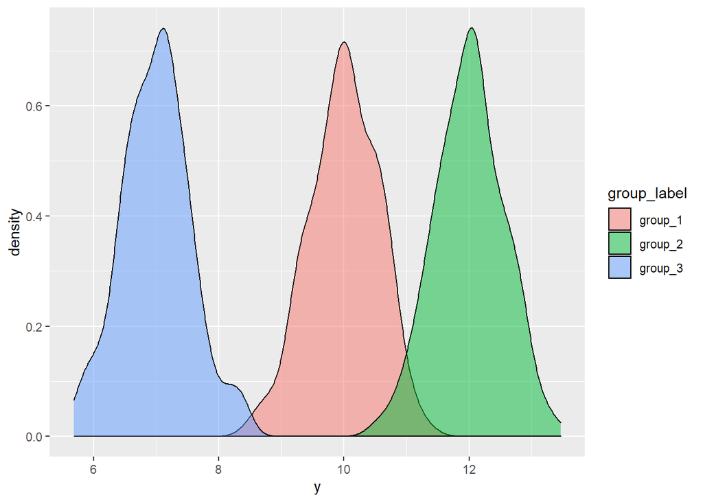

```r
# Step 6 - turn into density plots for easier viewing (how t-tests are usually displayed)
ggplot(data = df, aes(x = y, group = group_label, fill = group_label)) +
  geom_density(alpha = 0.5)
```

### Two-way/Factorial ANOVA

The model for a two-way ANOVA with interactions includes:

- Main effect of variable 1
- Main effect of variable 2
- Interactions between each level of variable 1 and level 2
- error

#### Example equations

Variable 1 has two levels, variable 2 has three levels, with an interaction term:

$$y = \beta_0 + \beta_1X_1 + \beta_2X_2 + \beta_3X_1X_2$$
Where:

In R it is written as follows:

```r
lm(outcome_var ~ 1 + # the 1 is included to indicate $1*B0/intercept
   var1_level2 + var2_level2 + var2_level3 + # main effects
     var1_level2*var2_level2 + var1_level2*var2_level3) # interaction terms
```

### ANCOVA - multiple groups (categorical) and a continuous predictor

ANCOVA is an extension of ANOVA where you control for one or more covariates.

A covariate is a continuous variable that is correlated with the dependent variable but is not the focus of the study.

In an ANOVA, the variance due to covariates becomes error. If it is controlled in an ANCOVA, then the error variance is less, so you more accurately assess the variance due to the factor (the IV).

Assumptions:

- **ANOVA assumptions - normality and homogeneity of variance**
- **Linearity between pairs of covariates** - if there is more than one covariate
- **Linearity between the covariates and the DV**
- **Homogeneity of regression** - the regression slope between the continuous predictor and outcome variable should be the same for all groups, or there should be no interaction between the continuous predictor and group levels in predicting the outcome variable.
- **Independence of covariate and factor** - the categorical and continuous predictors should be independent

```r
# Parameters
group_size <- 200
mean_g1 <- 10
mean_g2 <- 12
mean_g3 <- 7
sd_g1 <- 0.3
sd_g2 <- 0.3
sd_g3 <- 0.3
n_groups <- 3

# Data generation
group_1 <- mvrnorm(n = group_size, mu = mean_g1, Sigma = sd_g1, empirical = TRUE)
group_2 <- mvrnorm(n = group_size, mu = mean_g2, Sigma = sd_g2, empirical = TRUE)
group_3 <- mvrnorm(n = group_size, mu = mean_g3, Sigma = sd_g3, empirical = TRUE)
data <- c(group_1, group_2, group_3)
continuous <-data + mvrnorm(n = group_size*n_groups, mu = 0, Sigma = 2, empirical = TRUE)

# Data frame
df <- tibble(group_label = rep(c("group_1", "group_2", "group_3"), each = group_size),
             group_n = as_factor(rep(c(0, 1, 2), each = group_size)),
             group_2 = rep(c(0,1,0), each = group_size),
             group_3 = rep(c(0,0,1), each = group_size),
             y = data,
             x = continuous)
```

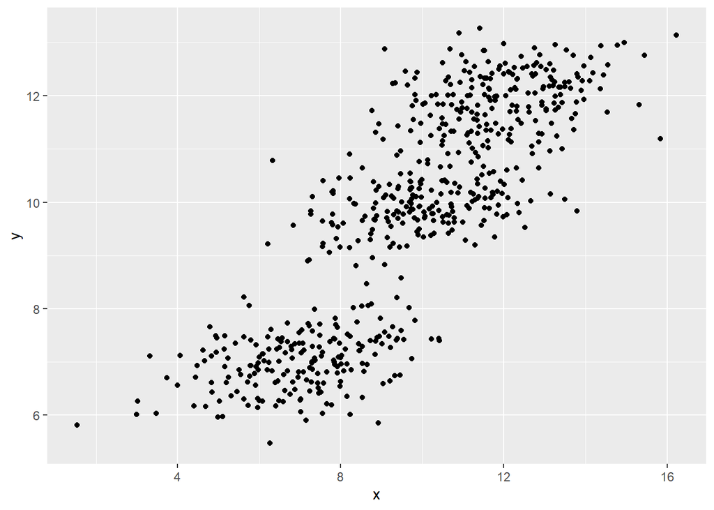

```r
ggplot(data = df, mapping = aes(x = x, y = y)) +
  geom_point()
```